# HW1

Group 8

7 May 2024

Group :

Lisa Bensousan - 346462534 - lisa.bensoussan@mail.huji.ac.il  
Dan Levy - 346453202 - dan.levy5@mail.huji.ac.il  
Emmanuelle Fareau - 342687233 - emmanuel.fareau@mail.huji.ac.il

### Libraries used :

```r
library(stringr)
library(ggplot2)
library(dplyr)
library(tidyr)
```

### Paths and Data :

```r
load("C:/Users/Emmanuelle Fareau/Downloads/chr1_str_30M_50M.rda")
```

## Introduction :

In this study, we want to analyze the genes of the chromosome 1 data and we focus on the region between 30 and 50 million. We want to see how the bases are distributed and if we can notice a repeating pattern and a certain coherence.

## Part 1:

In this question, we load the file of chromosome 1 data and focus on the region between 30 and 50 million.

```r
load("C:/Users/Emmanuelle Fareau/Downloads/chr1_str_30M_50M.rda")
```

## Part 2 :

In this question we want to create a function which allows us to calculate the number of occurrences for each letter in a region of size 1000. To do this, we must create a function which allows us to enter the start variable to know on which region each time we have to concentrate. We use `table` to report the number of occurrences for each letter in the cell sequence.

```r
calculate_single_cell_counts <- function(genome_sequence, cell_size, gene_start) {
  start_index <- gene_start
  end_index <- min(gene_start + cell_size - 1, nchar(genome_sequence))
  cell_sequence <- substr(genome_sequence, start_index, end_index) # extract the sequence
  cell_base_counts <- table(strsplit(cell_sequence, "")) # count the bases in the cell sequence
  return(cell_base_counts)
}
```

We test this function on our dataset with a cell size of 1000 bases, and a gene_start at position 100 :

```r
genome_sequence <- chr1_str_30M_50M
cell_size <- 1000
gene_start <- 100
result <- calculate_single_cell_counts(genome_sequence, cell_size, gene_start)


print(result)
```

```
##
##   A   C   G   T
## 227 233 351 189
```

In this example of region, we can notice a more significant presence of G than of the other letters.

## Part 3 :

In this question, we want to graphically represent the distribution of all bases (A,C,G,T), using a histogram.  
For that, fist of all we use `table` in the entire genomic sequence to obtain the table with the number of occurrences for each letter.  
After this, we need to transform the table that we have acquired to data frame in order to be able to use `ggplot` and create a histogram of these values.

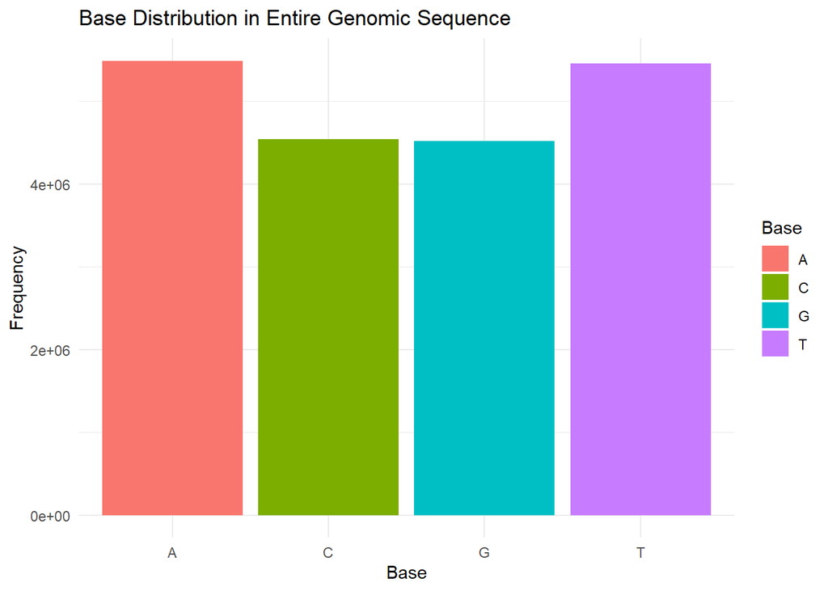

```r
base_counts <- table(strsplit(chr1_str_30M_50M, ""))

base_data <- as.data.frame(base_counts)
names(base_data) <- c("Base", "Frequency")

plot <- ggplot(base_data, aes(x = Base, y = Frequency, fill = Base)) +
  geom_bar(stat = "identity") +
  labs(title = "Base Distribution in Entire Genomic Sequence",
       x = "Base",
       y = "Frequency") +
  theme_minimal()

print(plot)
```

We obtained a histogram which represents the frequency of each base in our genetic sequence.  
We can see thanks to this histogram that the bases A and T which are connected to each other have approximately the same number of occurrences and it is the same for the couple C and G.

## Part 4 :

We want to create a plot for each base (A,C,G,T) and calculate for each region the number of occurrences of that base. We’ll therefore obtain a plot with the place in the chromosome on the abcissa and the number of occurrences of the base concerned on the ordinate.  
We create function to calculate letter frequency in a sequence like in the previous question and we create an other function to divide our sequence into intervals. After that, we draw our histograms for each base.

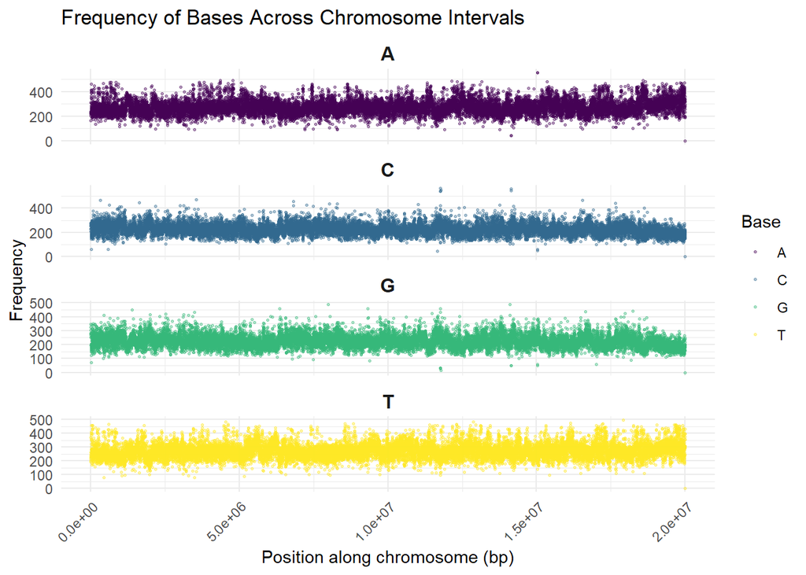

```r
interval_length <- 1000

calculate_letter_frequency <- function(sequence) {
    freq <- table(strsplit(sequence, ""))
    expected_bases <- c("A", "C", "G", "T")
    freq <- as.numeric(freq[expected_bases])
    names(freq) <- expected_bases
    if (any(is.na(freq))) {
        freq[is.na(freq)] <- 0  # replace NA with 0 for bases not present in the sequence slice
    }
    return(freq)
}

# Function to divide sequence into intervals and calculate frequencies :

calculate_frequency_in_intervals <- function(sequence, interval_length) {
    n <- nchar(sequence)
    intervals <- seq(1, n, by = interval_length)
    data <- tibble(
        Start = intervals,
        End = pmin(intervals + interval_length - 1, n),
        Frequencies = vector("list", length(intervals))
    )
    for (i in seq_along(intervals)) {
        start <- intervals[i]
        end <- pmin(start + interval_length - 1, n)
        subseq <- substring(sequence, start, end)
        data$Frequencies[[i]] <- calculate_letter_frequency(subseq)
    }
    return(data)
}

# Calculate frequencies in intervals :
frequencies_df <- calculate_frequency_in_intervals(genome_sequence, interval_length)

# Transform list-column into a tidy format :

data_long <- frequencies_df %>%
  unnest_wider(col = Frequencies) %>%
  pivot_longer(
    cols = c("A", "C", "G", "T"),
    names_to = "Base",
    values_to = "Frequency"
  ) %>%
  mutate(Frequency = as.numeric(Frequency))

# Plotting the data :
ggplot(data_long, aes(x = Start, y = Frequency, color = Base)) +
  geom_point(alpha = 0.4, size = 0.5) +
  facet_wrap(~ Base, scales = "free_y", ncol = 1) +
  scale_color_viridis_d() +
  labs(title = "Frequency of Bases Across Chromosome Intervals",
       x = "Position along chromosome (bp)",
       y = "Frequency",
       color = "Base") +
  theme_minimal() +
  theme(strip.background = element_blank(),
        strip.text = element_text(size = 12, face = "bold"),
        axis.text.x = element_text(angle = 45, hjust = 1))
```

## Part 5:

Here we want to draw a scatter plot of the frequency of each base pair in the same cell.

```r
# Function to calculate base pair frequency in a sequence :

calculate_base_pair_frequency <- function(sequence) {
  bases <- strsplit(sequence, "")[[1]]

  base_pair_freq <- matrix(0, nrow = 4, ncol = 4)
  rownames(base_pair_freq) <- colnames(base_pair_freq) <- c("A", "C", "G", "T")

  # Calculate base pair frequencies :

  for (i in 1:(length(bases) - 1)) {
    base1 <- bases[i]
    base2 <- bases[i + 1]
    base_pair_freq[base1, base2] <- base_pair_freq[base1, base2] + 1
  }

  return(base_pair_freq)
}

# Calculate base pair frequencies :

base_pair_freq <- calculate_base_pair_frequency(genome_sequence)
print(base_pair_freq)
```

```
##         A       C       G       T
## A 1682450 1014954 1503632 1286600
## C 1507442 1285824  240632 1507532
## G 1223917 1015793 1277603 1000340
## T 1073827 1224859 1495786 1658809
```

```r
row_sums <- rowSums(base_pair_freq)  # we calculate the row sums

transition_frequencies <- sweep(base_pair_freq, 1, row_sums, "/") #switch frequencies

print(transition_frequencies)
```

```
##           A         C          G         T
## A 0.3065892 0.1849529 0.27400360 0.2344543
## C 0.3319311 0.2831320 0.05298595 0.3319509
## G 0.2709188 0.2248497 0.28280238 0.2214291
## T 0.1969139 0.2246096 0.27429102 0.3041855
```

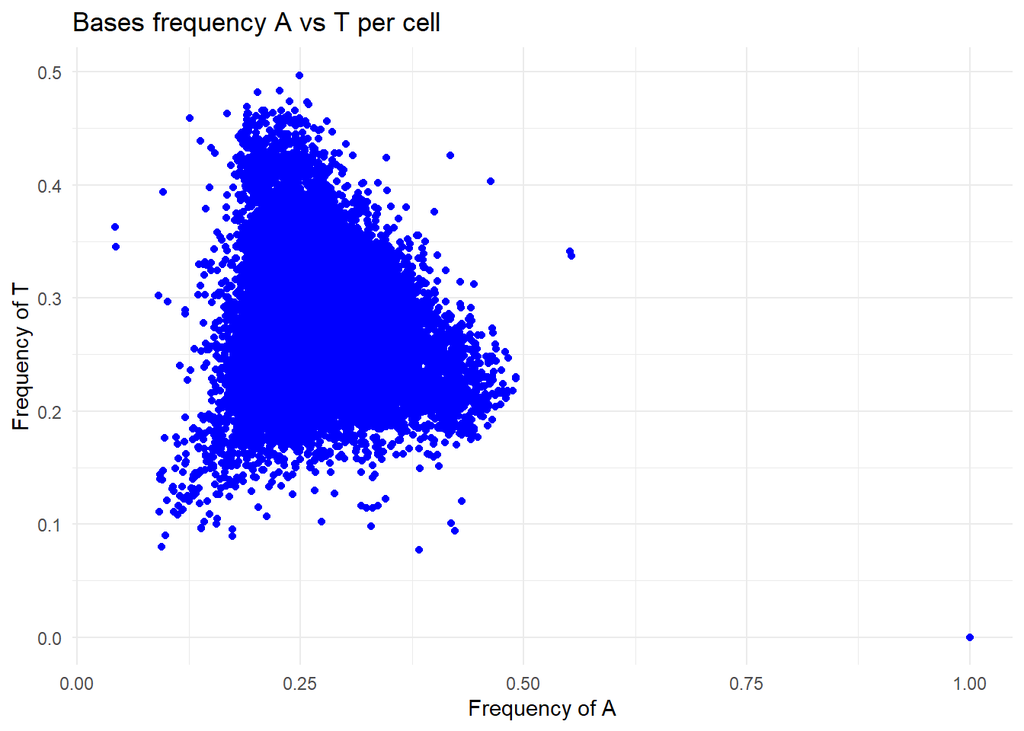

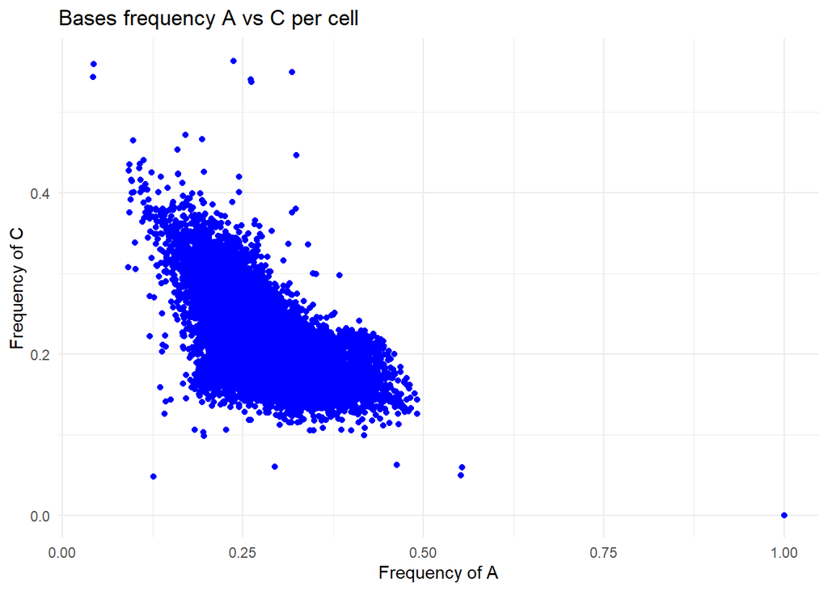

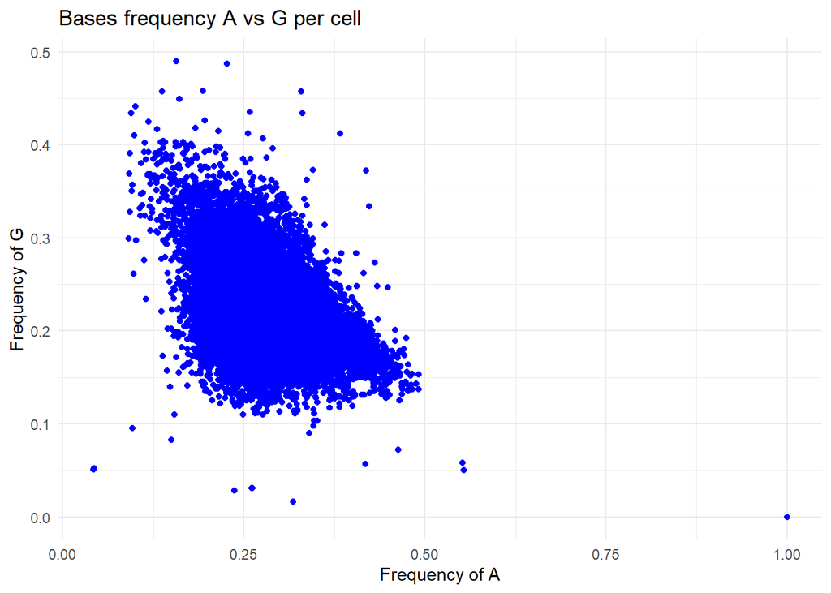

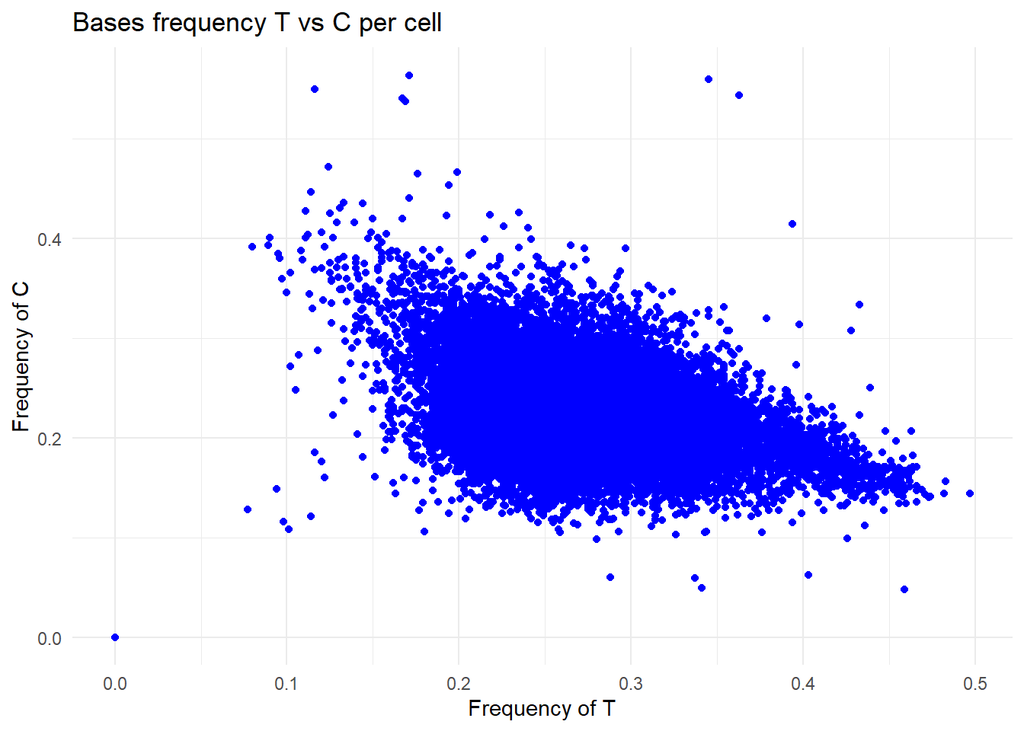

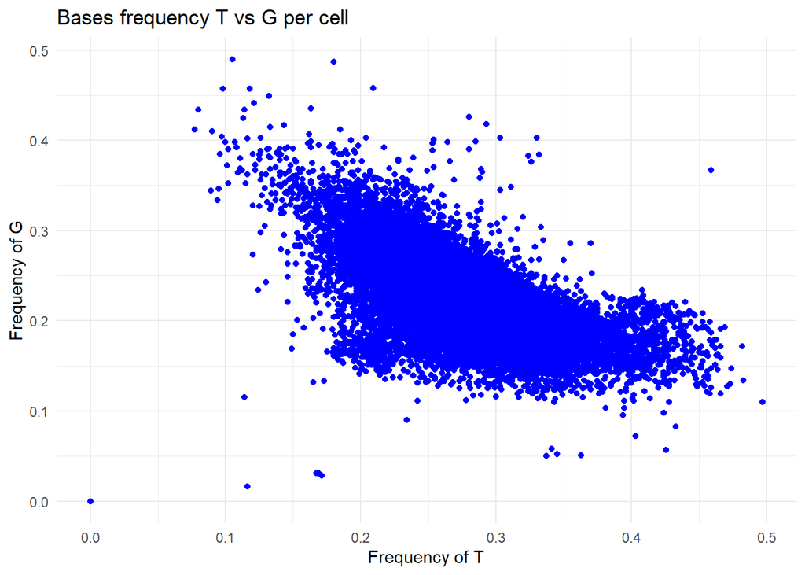

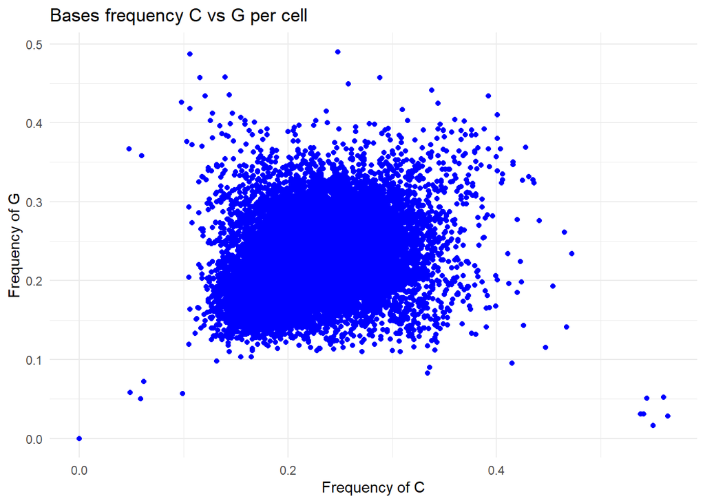

```r
calculate_base_frequencies <- function(genome_sequence, cell_size) {
  num_cells <- ceiling(nchar(genome_sequence) / cell_size)

  base_frequencies <- data.frame(
    cell = integer(),
    A = numeric(),
    T = numeric(),
    C = numeric(),
    G = numeric()
  )

  for (i in 1:num_cells) {
    start_index <- (i - 1) * cell_size + 1
    end_index <- min(i * cell_size, nchar(genome_sequence))
    cell_sequence <- substr(genome_sequence, start_index, end_index)
    base_counts <- table(factor(strsplit(cell_sequence, "")[[1]], levels = c("A", "T", "C", "G")))
    total_bases <- sum(base_counts)
    base_freq <- base_counts / total_bases

    base_frequencies <- rbind(base_frequencies, data.frame(
      cell = i,
      A = base_freq["A"],
      T = base_freq["T"],
      C = base_freq["C"],
      G = base_freq["G"]
    ))
  }

  return(base_frequencies)
}


create_scatter_plot <- function(base_frequencies, base1, base2) {
  ggplot(base_frequencies, aes_string(x = base1, y = base2)) +
    geom_point(color = "blue") +
    labs(title = paste("Bases frequency", base1, "vs", base2, "per cell"),
         x = paste("Frequency of", base1),
         y = paste("Frequency of", base2)) +
    theme_minimal()
}


identify_unusual_cells <- function(base_frequencies, threshold = 0.05) {
  unusual_cells <- base_frequencies %>%
    filter(A > threshold | T > threshold | C > threshold | G > threshold)

  return(unusual_cells)
}


base_frequencies <- calculate_base_frequencies(genome_sequence, cell_size)


pairs <- list(c("A", "T"), c("A", "C"), c("A", "G"), c("T", "C"), c("T", "G"), c("C", "G"))
plots <- lapply(pairs, function(pair) create_scatter_plot(base_frequencies, pair[1], pair[2]))
for (plot in plots) {
  print(plot)
}
```

### c.

Here, we want to observe the pair CG and see where this pair appears in our chromosome.

We create function to count CG pairs in a sequence and we create function to divide sequence into intervals and count CG pairs

```r
calculate_cg_frequency <- function(sequence) {
  cg_count <- sum(str_count(sequence, "CG"))
  return(cg_count)
}

calculate_cg_frequencies_in_intervals <- function(sequence, interval_length) {
  intervals <- seq(1, nchar(sequence), by = interval_length)
  cg_counts <- sapply(intervals, function(start) {
    end <- min(start + interval_length - 1, nchar(sequence))
    interval_sequence <- substr(sequence, start, end)
    calculate_cg_frequency(interval_sequence)
  })
  return(cg_counts)
}
```

We use these functions with our genome data.

[figure not shown]

```r
interval_length <- 20000

cg_frequencies <- calculate_cg_frequencies_in_intervals(genome_sequence, interval_length)

interval_starts <- seq(1, by = interval_length, length.out = length(cg_frequencies))
labels_mb <- paste0(round(interval_starts / interval_length, 2), " Mb")


df <- data.frame(Intervals = labels_mb, Frequency = cg_frequencies)
ggplot(df, aes(x = Intervals, y = Frequency, fill = Intervals)) +
  geom_bar(stat = "identity", color = "salmon", show.legend = FALSE) +
  theme_minimal() +
  labs(title = "Frequency of 'CG' Pairs Across Intervals",
       x = "Position on Chromosome (Mb)", y = "Frequency of 'CG'")
```

We can see that it is not uniformly distributed and at some points there are some peaks very lows and at other points there are some peaks very high.

We can see that in generally CG pairs appears consecutively.

## Part 6 :

We create a mosaic plot for base pair frequencies with the previous code to visualize and found with which bases we want to create a pair.

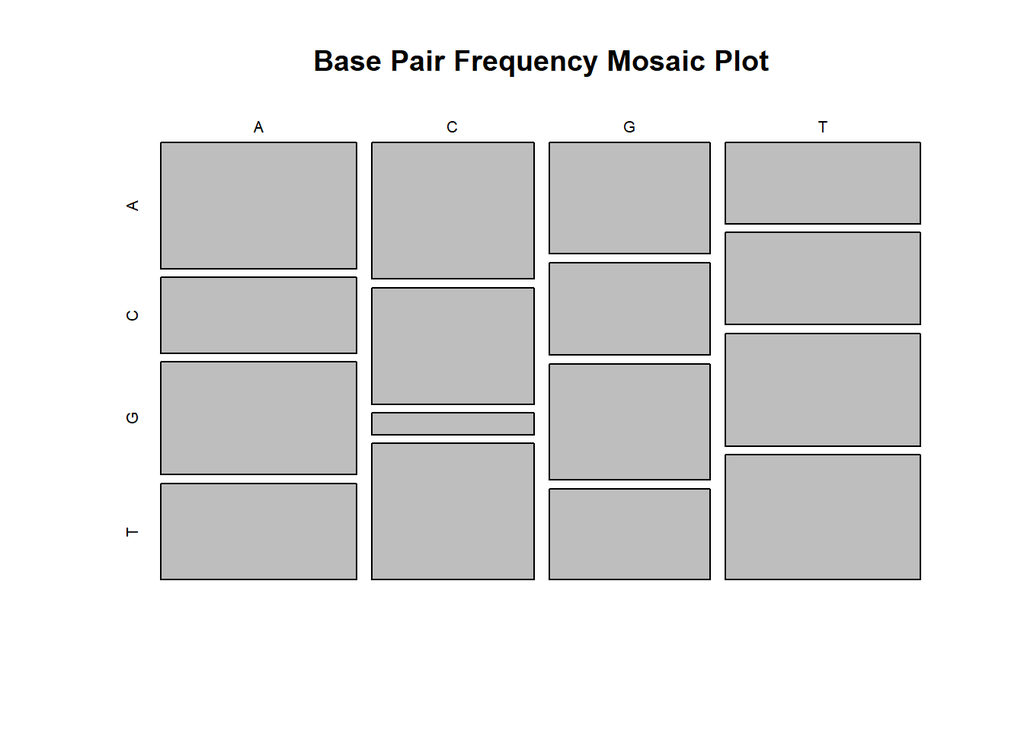

```r
mosaicplot(base_pair_freq, main = "Base Pair Frequency Mosaic Plot")
```

If we had to divide the four bases in two pairs, we would divide them like this: “AG” and “CT” because like we can see on the mosaic that we did, the bases A and G often follow each others and the same thing for the bases C and T. It seem like they tend to be as a pair.

## Short summary :

In conclusion, this study focuses on analyzing the genes located between 30 and 50 million base pairs of chromosome 1, with a particular interest in the distribution of bases and the search for recurring and coherent patterns.

Our analyses reveal, thanks to a histogram that representing the distribution of the bases, that the bases A and T, which are often associated, have similar occurrences and they are more present. And the bases C and G are often associated.

We found also that CG pair doesn’t follow a trend like the others pairs.

These observations may suggest specific characteristics of the genomic structure in this region of chromosome 1, providing avenues for future research.